# Analyses: drivers of recruitment

Anna Talucci

July 19, 2019

```r
rm(list=ls())
```

# Overview

For short interval beetle+fire disturbances we are interested if time since beetle attack impacts the aerial seedbank and subsequent regeneration after fire. Seedling count data was acquired over various sized plots; in order to account for this we analyzed out data as a negative bionomial and accounted for the effort of the seedling count collection. Effort refers to the log of the area in which seedlings were counted in.

The goal of this analysis is twofold. First, to assess seedling density as a function of plots burning or not burning. Second, to assess seedling density as a function of the type of burning conditions - unburned, surface, severe surface, and crown.

# Packages

The following Packages are required for the below analyses:

```r
library(dplyr)
library(tidyr)
library(ggplot2)
library(MASS)
library(car)
library(lme4)
library(DHARMa)
library(lsmeans)
library(cowplot)
library(RColorBrewer)
library(DT)
library(GGally) # ggpairs
```

# Data

Read in burned plot data

```r
fire = read.csv("../data/2018-09-20_ch2-burnedplots-wcodes-edit43.csv", header = TRUE, sep = ",", strip.white = TRUE)

summary(fire)
```

```
##       plot          Plot_ID      plot.mpb      stems
##  Min.   : 1.0   BA0719L1: 1   HH7    : 1   Min.   : 2.00
##  1st Qu.:16.5   BA0719M1: 1   HL18   : 1   1st Qu.: 9.50
##  Median :32.0   BA0719M2: 1   HL24   : 1   Median :12.00
##  Mean   :32.0   BA0720H1: 1   HL44   : 1   Mean   :14.44
##  3rd Qu.:47.5   BA0720H2: 1   HL46   : 1   3rd Qu.:18.00
##  Max.   :63.0   BA0720L1: 1   HL54   : 1   Max.   :42.00
##                 (Other) :57   (Other):57
##       bom              fire             live              upf
##  Min.   : 0.000   Min.   : 0.000   Min.   : 0.0000   Min.   : 0.00
##  1st Qu.: 3.500   1st Qu.: 0.000   1st Qu.: 0.0000   1st Qu.: 0.00
##  Median : 9.000   Median : 2.000   Median : 0.0000   Median : 0.00
##  Mean   : 8.476   Mean   : 3.825   Mean   : 0.6825   Mean   : 1.46
##  3rd Qu.:12.500   3rd Qu.: 5.000   3rd Qu.: 0.0000   3rd Qu.: 0.50
##  Max.   :22.000   Max.   :28.000   Max.   :11.0000   Max.   :15.00
##
##    no.canopy       yes.canopy        no.seed          yes.seed
##  Min.   : 0.00   Min.   : 0.000   Min.   : 0.000   Min.   : 0.000
##  1st Qu.: 0.50   1st Qu.: 4.000   1st Qu.: 5.000   1st Qu.: 2.000
##  Median : 4.00   Median : 8.000   Median : 8.000   Median : 4.000
##  Mean   : 4.73   Mean   : 9.714   Mean   : 9.016   Mean   : 5.413
##  3rd Qu.: 7.50   3rd Qu.:13.000   3rd Qu.:12.500   3rd Qu.: 7.000
##  Max.   :18.00   Max.   :38.000   Max.   :28.000   Max.   :28.000
##
##     tot.stem        cone.ct      seed.density         disturbance
##  Min.   : 2.00   Min.   :   0   Min.   :   2.0   beetle+fire:63
##  1st Qu.: 9.50   1st Qu.: 235   1st Qu.:  34.0
##  Median :12.00   Median : 680   Median :  75.0
##  Mean   :14.44   Mean   : 905   Mean   : 170.7
##  3rd Qu.:18.00   3rd Qu.:1366   3rd Qu.: 187.5
##  Max.   :42.00   Max.   :3665   Max.   :1700.0
##
##     fire.type      burncon
##  crown   :21   extreme :21
##  sev.surf:20   moderate:42
##  surface :22
##
##
##
##
```

Readin data for seedling effort (area collected)

```r
fire.seedeffort = read.csv("../data/chapter2_analysis34_seedlingeffort_11december2017.csv", header = TRUE, sep = ",", strip.white = TRUE)

summary(fire.seedeffort)
```

```
##       plot       seedling.ct     seedling.area
##  Min.   : 1.0   Min.   :  0.00   Min.   :  4.00
##  1st Qu.:16.5   1st Qu.:  6.50   1st Qu.: 51.00
##  Median :32.0   Median : 22.00   Median : 52.00
##  Mean   :32.0   Mean   : 50.97   Mean   : 42.81
##  3rd Qu.:47.5   3rd Qu.: 67.00   3rd Qu.: 52.00
##  Max.   :63.0   Max.   :538.00   Max.   :100.00
```

Combine seedling effort data with burn plot data

```r
fire2 = merge(fire, fire.seedeffort, by = c("plot"))
head(fire2)
```

```
##   plot   Plot_ID plot.mpb stems bom fire live upf no.canopy yes.canopy
## 1    1 CEC0629M1      LM1     7   0    7    0   0         0          7
## 2    2 CEC0630H1      LM2     7   0    7    0   0         0          7
## 3    3 CEC0701L1      LL3    42  17   21    3   1         4         38
## 4    4 CEC0702M1      HM4    12  12    0    0   0         0         12
## 5    5 CEC0702H1      LH5    24   0    9    0  15        15          9
## 6    6 CEC0703M1      LL6    20  16    4    0   0        10         10
##   no.seed yes.seed tot.stem cone.ct seed.density disturbance fire.type
## 1       0        7        7     282           75 beetle+fire  sev.surf
## 2       0        7        7    1150         1700 beetle+fire  sev.surf
## 3      28       14       42    3665          375 beetle+fire   surface
## 4       6        6       12    1286          150 beetle+fire  sev.surf
## 5      15        9       24    1585          375 beetle+fire     crown
## 6      15        5       20     680            2 beetle+fire   surface
##    burncon seedling.ct seedling.area
## 1 moderate           3             4
## 2 moderate          68             4
## 3 moderate          15             4
## 4 moderate           6             4
## 5 moderate          15             4
## 6 moderate           0             4
```

```r
str(fire2)
```

```
## 'data.frame':    63 obs. of  20 variables:
##  $ plot         : int  1 2 3 4 5 6 7 8 9 10 ...
##  $ Plot_ID      : Factor w/ 63 levels "BA0719L1","BA0719M1",..: 24 25 26 28 27 29 30 31 32 33 ...
##  $ plot.mpb     : Factor w/ 63 levels "HH7","HL18","HL24",..: 35 36 27 9 21 33 1 48 12 13 ...
##  $ stems        : int  7 7 42 12 24 20 6 11 14 11 ...
##  $ bom          : int  0 0 17 12 0 16 6 11 14 0 ...
##  $ fire         : int  7 7 21 0 9 4 0 0 0 2 ...
##  $ live         : int  0 0 3 0 0 0 0 0 0 0 ...
##  $ upf          : int  0 0 1 0 15 0 0 0 0 9 ...
##  $ no.canopy    : int  0 0 4 0 15 10 6 11 14 9 ...
##  $ yes.canopy   : int  7 7 38 12 9 10 0 0 0 2 ...
##  $ no.seed      : int  0 0 28 6 15 15 6 11 14 9 ...
##  $ yes.seed     : int  7 7 14 6 9 5 0 0 0 2 ...
##  $ tot.stem     : int  7 7 42 12 24 20 6 11 14 11 ...
##  $ cone.ct      : int  282 1150 3665 1286 1585 680 0 0 0 170 ...
##  $ seed.density : int  75 1700 375 150 375 2 100 150 150 125 ...
##  $ disturbance  : Factor w/ 1 level "beetle+fire": 1 1 1 1 1 1 1 1 1 1 ...
##  $ fire.type    : Factor w/ 3 levels "crown","sev.surf",..: 2 2 3 2 1 3 1 1 1 1 ...
##  $ burncon      : Factor w/ 2 levels "extreme","moderate": 2 2 2 2 2 2 2 2 2 2 ...
##  $ seedling.ct  : int  3 68 15 6 15 0 4 6 6 5 ...
##  $ seedling.area: int  4 4 4 4 4 4 4 4 4 4 ...
```

Read data for surface variables (soil)

```r
surf.fire = read.csv("../data/surf_bom_utm.csv", header=TRUE, sep = ",", strip.white = TRUE)
head(surf.fire)
```

```
##   plot stems    gv ground.char  soil litter  rock dwood  cwd other deadveg
## 1    1     7 35.00      46.750 16.25  0.000  0.00  1.25 0.75  0.00       0
## 2    2     7 42.50      46.000  0.00  0.000 11.50  0.00 0.00  0.00       0
## 3    3    42 49.25       9.375  0.00 37.875  2.25  0.00 0.00  1.25       0
## 4    4    12 50.00       2.500  0.00 47.500  0.00  0.00 0.00  0.00       0
## 5    5    24 26.25      47.000 25.00  0.000  1.75  0.00 0.00  0.00       0
## 6    6    20 52.00      18.000  1.25 23.750  0.00  0.00 0.50  0.00       0
##   duff.depth subplot quadplot fire mpb unk opf live DC1 DC2 DC3 DC4   topo
## 1   0.875000    0.75       NA    7   0   0   0    0   7   0   0   0 -0.185
## 2   0.675000   17.00       NA    7   0   0   0    0   7   0   0   0  0.048
## 3   0.925000    3.75       NA   21   3  10   7    1  26  16   0   0 -0.111
## 4   1.366667    1.50       NA    0   0   3   9    0   0  12   0   0 -0.111
## 5   0.600000    3.75       NA    9   0  15   0    0   9   0  15   0 -0.056
## 6   1.125000    0.00       NA    4   0  10   6    0   6  12   2   0  0.111
##    fwi pfm deep.char burn.cond   prop.mpb  prop.pfm plot.mpb species tpha
```

[output cut: 20 more lines]

```r
soil = surf.fire %>%
    dplyr::select(plot, stems, soil)

head(soil)
```

```
##   plot stems  soil
## 1    1     7 16.25
## 2    2     7  0.00
## 3    3    42  0.00
## 4    4    12  0.00
## 5    5    24 25.00
## 6    6    20  1.25
```

Create a variable called prop.soil by converted from continuous percent to continuous proportion

```r
soil = transform(soil, prop.soil = soil*0.01)
head(soil)
```

```
##   plot stems  soil prop.soil
## 1    1     7 16.25    0.1625
## 2    2     7  0.00    0.0000
## 3    3    42  0.00    0.0000
## 4    4    12  0.00    0.0000
## 5    5    24 25.00    0.2500
## 6    6    20  1.25    0.0125
```

Add soil data to data frame created above called fire2

```r
fire2 = merge(fire2, soil, by = c("plot", "stems"))
head(fire2)
```

```
##   plot stems   Plot_ID plot.mpb bom fire live upf no.canopy yes.canopy
## 1    1     7 CEC0629M1      LM1   0    7    0   0         0          7
## 2   10    11 CEC0705H4     LH10   0    2    0   9         9          2
## 3   11     6 CEC0705H5     LH11   6    0    0   0         6          0
## 4   12    18 CEC0706L1     LL12   9    8    1   0         1         17
## 5   13    18 CEC0706L2     ML13  12    4    2   0         0         18
## 6   14    10 CEC0706L3     ML14   7    2    1   0         0         10
##   no.seed yes.seed tot.stem cone.ct seed.density disturbance fire.type
## 1       0        7        7     282           75 beetle+fire  sev.surf
## 2       9        2       11     170          125 beetle+fire     crown
## 3       6        0        6       0           75 beetle+fire     crown
## 4      13        5       18    1160          325 beetle+fire   surface
## 5      15        3       18    2389          200 beetle+fire   surface
## 6       2        8       10    1040            2 beetle+fire   surface
##    burncon seedling.ct seedling.area  soil prop.soil
## 1 moderate           3             4 16.25    0.1625
## 2 moderate           5             4 69.00    0.6900
## 3 moderate           3             4 19.50    0.1950
## 4 moderate          13             4  3.75    0.0375
## 5 moderate           8             4  0.00    0.0000
## 6 moderate           0             4  1.25    0.0125
```

```r
dc = surf.fire %>%
    dplyr::select(plot, stems, DC1:DC4, deep.char) %>%
    mutate(noDC = DC1) %>%
    mutate(partDC = DC2) %>%
    mutate(fullDC = DC3 + DC4) %>%
    mutate(allDC = deep.char)

head(dc)
```

```
##   plot stems DC1 DC2 DC3 DC4 deep.char noDC partDC fullDC allDC
## 1    1     7   7   0   0   0         0    7      0      0     0
## 2    2     7   7   0   0   0         0    7      0      0     0
## 3    3    42  26  16   0   0        16   26     16      0    16
## 4    4    12   0  12   0   0        12    0     12      0    12
## 5    5    24   9   0  15   0        15    9      0     15    15
## 6    6    20   6  12   2   0        14    6     12      2    14
```

```r
dc = dc %>%
    dplyr::select(plot, stems, noDC:allDC)
head(dc)
```

```
##   plot stems noDC partDC fullDC allDC
## 1    1     7    7      0      0     0
## 2    2     7    7      0      0     0
## 3    3    42   26     16      0    16
## 4    4    12    0     12      0    12
## 5    5    24    9      0     15    15
## 6    6    20    6     12      2    14
```

```r
fire2 = merge(fire2, dc, by = c("plot", "stems"))
head(fire2)
```

```
##   plot stems   Plot_ID plot.mpb bom fire live upf no.canopy yes.canopy
## 1    1     7 CEC0629M1      LM1   0    7    0   0         0          7
## 2   10    11 CEC0705H4     LH10   0    2    0   9         9          2
## 3   11     6 CEC0705H5     LH11   6    0    0   0         6          0
## 4   12    18 CEC0706L1     LL12   9    8    1   0         1         17
## 5   13    18 CEC0706L2     ML13  12    4    2   0         0         18
## 6   14    10 CEC0706L3     ML14   7    2    1   0         0         10
##   no.seed yes.seed tot.stem cone.ct seed.density disturbance fire.type
## 1       0        7        7     282           75 beetle+fire  sev.surf
## 2       9        2       11     170          125 beetle+fire     crown
## 3       6        0        6       0           75 beetle+fire     crown
## 4      13        5       18    1160          325 beetle+fire   surface
## 5      15        3       18    2389          200 beetle+fire   surface
## 6       2        8       10    1040            2 beetle+fire   surface
##    burncon seedling.ct seedling.area  soil prop.soil noDC partDC fullDC
## 1 moderate           3             4 16.25    0.1625    7      0      0
## 2 moderate           5             4 69.00    0.6900    2      1      8
## 3 moderate           3             4 19.50    0.1950    0      0      6
## 4 moderate          13             4  3.75    0.0375    9      9      0
## 5 moderate           8             4  0.00    0.0000    7     11      0
## 6 moderate           0             4  1.25    0.0125    3      7      0
##   allDC
## 1     0
## 2     9
## 3     6
## 4     9
## 5    11
## 6     7
```

Read in Coarse Woody Debris (CWD) data

```r
cwddata = read.csv("../data/2018-09-25_ch2_cwd.csv", header = TRUE, sep = ",", strip.white = TRUE)

summary(cwddata)
```

```
##       plot          stems            cwd              live
##  Min.   : 1.0   Min.   : 7.00   Min.   : 0.000   Min.   : 0.0000
##  1st Qu.:16.5   1st Qu.:11.50   1st Qu.: 2.000   1st Qu.: 0.0000
##  Median :32.0   Median :16.00   Median : 5.000   Median : 0.0000
##  Mean   :32.0   Mean   :17.54   Mean   : 5.825   Mean   : 0.2222
##  3rd Qu.:47.5   3rd Qu.:21.50   3rd Qu.: 8.500   3rd Qu.: 0.0000
##  Max.   :63.0   Max.   :45.00   Max.   :19.000   Max.   :10.0000
##       snag        prefire.cwd     prefire.stem      prop.pfcwd
##  Min.   : 0.00   Min.   : 3.00   Min.   : 0.000   Min.   :0.3000
##  1st Qu.: 6.00   1st Qu.: 7.50   1st Qu.: 1.000   1st Qu.:0.6583
##  Median :10.00   Median :12.00   Median : 3.000   Median :0.7500
##  Mean   :11.49   Mean   :13.62   Mean   : 3.921   Mean   :0.7536
##  3rd Qu.:16.50   3rd Qu.:18.00   3rd Qu.: 6.000   3rd Qu.:0.9188
##  Max.   :42.00   Max.   :42.00   Max.   :18.000   Max.   :1.0000
##     prop.cwd       seedling.ct     seedling.area       fire.type
##  Min.   :0.0000   Min.   :  0.00   Min.   :  4.00   crown   :21
##  1st Qu.:0.1339   1st Qu.:  6.50   1st Qu.: 51.00   sev.surf:20
##  Median :0.3125   Median : 22.00   Median : 52.00   surface :22
##  Mean   :0.3666   Mean   : 50.97   Mean   : 42.81
##  3rd Qu.:0.5778   3rd Qu.: 67.00   3rd Qu.: 52.00
##  Max.   :1.0000   Max.   :538.00   Max.   :100.00
```

## Beetle+Fire Dataset

```r
fire2 = mutate(fire2, prop.bom = bom/stems)
fire2 = mutate(fire2, prop.prefire =  (bom + upf)/stems)
fire2 = mutate(fire2, prop.canopy = yes.canopy/stems)
fire2 = mutate(fire2, prop.nocanopy = no.canopy/stems)
fire2 = mutate(fire2, prop.opencone = yes.seed/stems)
fire2 = mutate(fire2, prop.closedcone = no.seed/stems)
fire2 = mutate(fire2, prop.cone.ct = cone.ct/stems)
fire2 = mutate(fire2, prop.fulldc = fullDC/stems)
fire2 = mutate(fire2, prop.partdc = partDC/stems)
fire2 = mutate(fire2, prop.nodc = noDC/stems)
fire2 = mutate(fire2, prop.alldc = allDC/stems)
```

# Data visualization

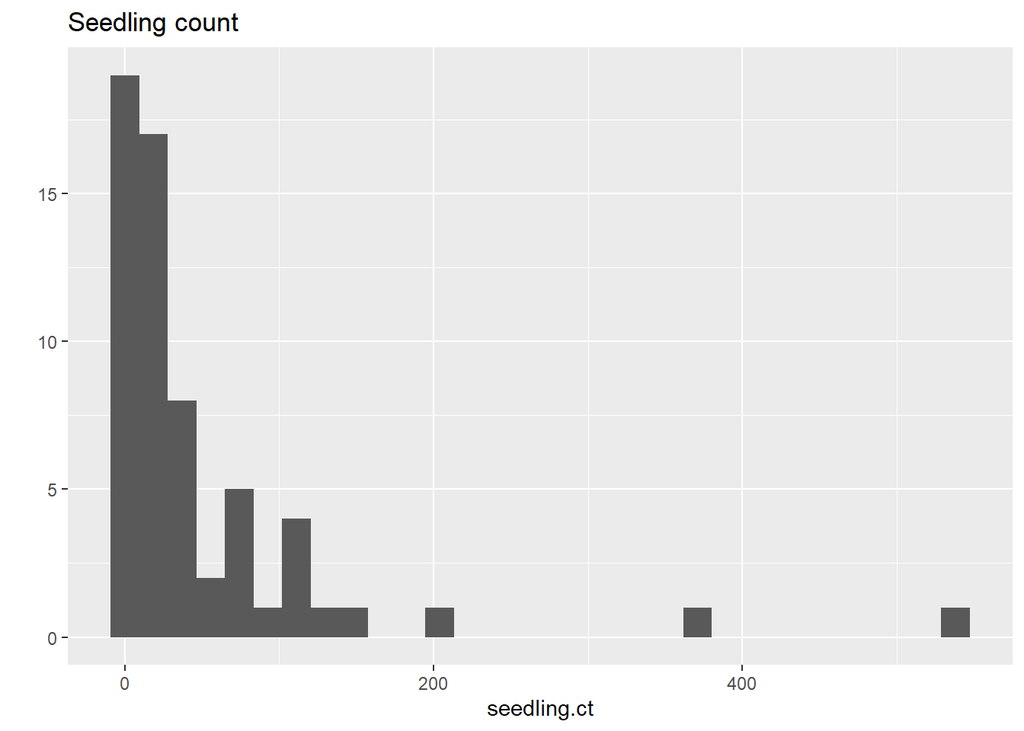

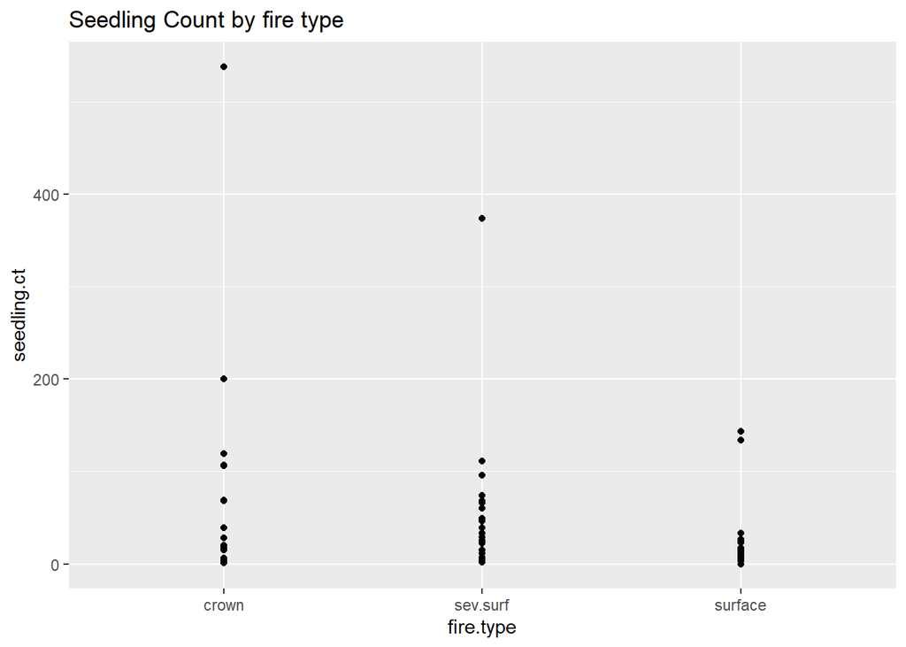

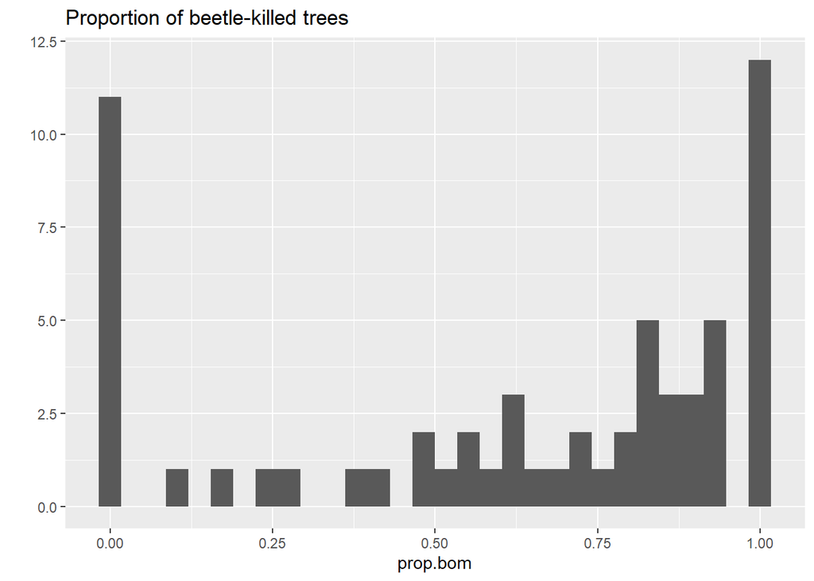

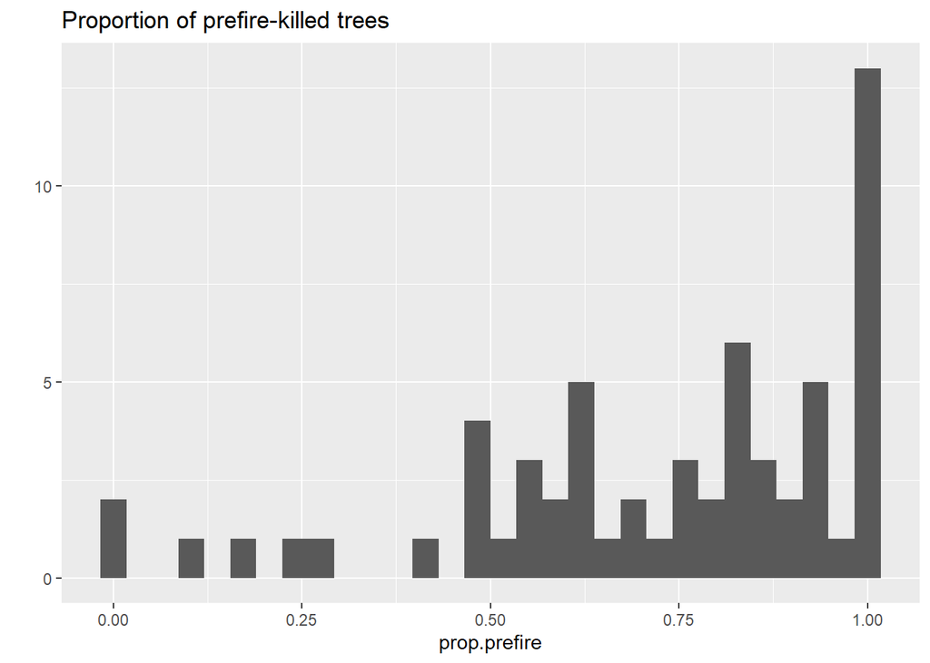

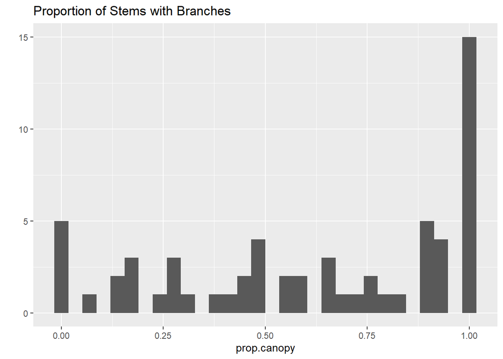

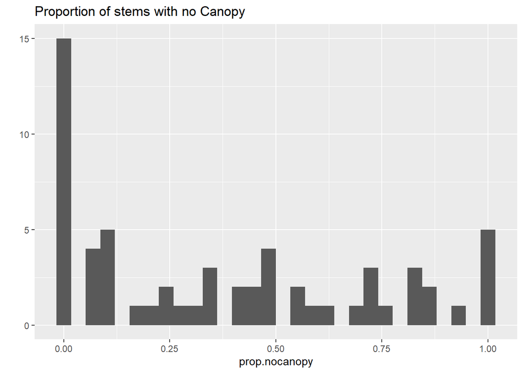

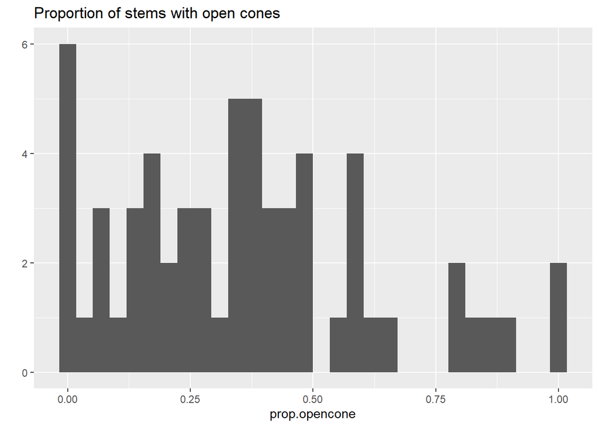

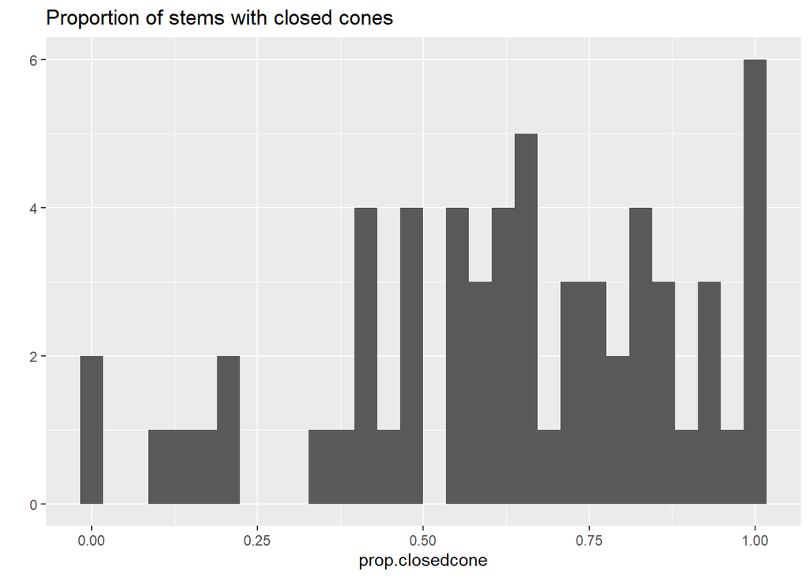

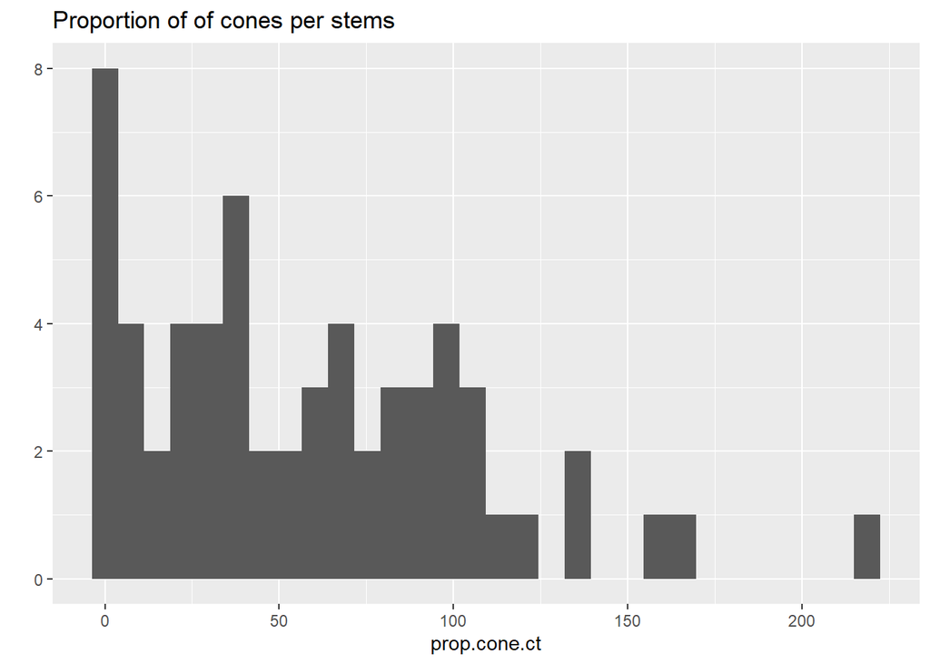

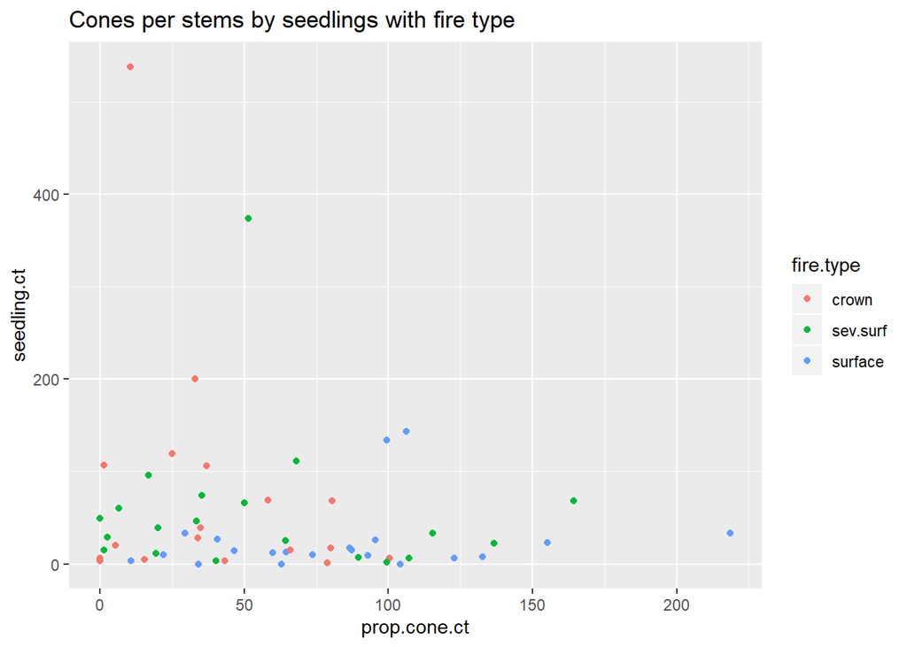

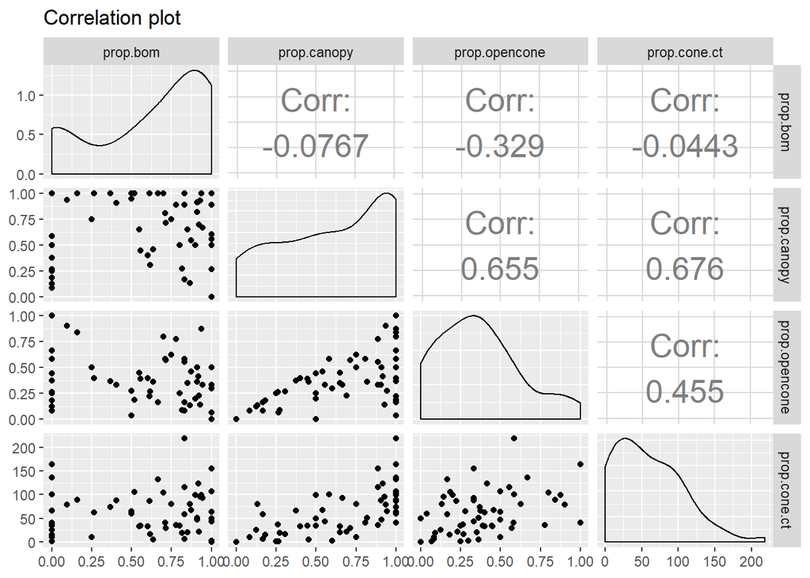

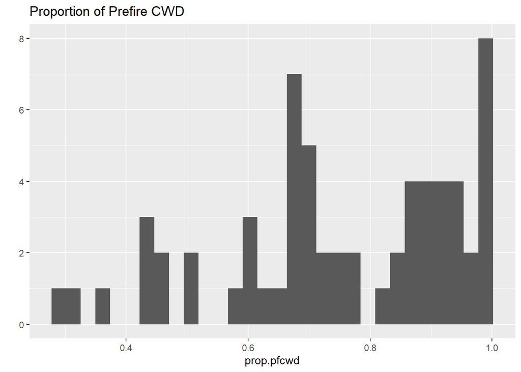

[1 more figures not shown]